# Gully Susceptibility using Logistic Regression

Babatunde Fagbohun

2024-06-03

```r
library(sf)
library(sp)
```

```r
library(tidyverse)
library(raster)
```

```r
library(mapview)
```

```r
library(rasterVis)
```

#reading in raster files

```r
ndvi <- raster("F:/DA/R/Gully_dataset/reclass_2018_ndv1.tif")
```

```r
aspect <- raster("F:/DA/R/Gully_dataset/aspect.tif")
```

```r
curvature <- raster("F:/DA/R/Gully_dataset/reclass_curvature.tif")
```

```r
elevation <- raster("F:/DA/R/Gully_dataset/reclass_elevationn.tif")
```

```r
erosivity <- raster("F:/DA/R/Gully_dataset/reclass_erosivity.tif")
```

```r
slope <- raster("F:/DA/R/Gully_dataset/reclass_slope.tif")
```

```r
twi <- raster("F:/DA/R/Gully_dataset/Reclass_TWI_filter_2nd1.tif")
```

```r
landuse <- raster("F:/DA/R/Gully_dataset/lulc_recl.tif")
```

```r
geology <- raster("F:/DA/R/Gully_dataset/reclass_geo.tif")
```

```r
soil <- raster("F:/DA/R/Gully_dataset/reclass_soil.tif")
```

#converting raster to a list file type

```r
raster_list <-as.list(ndvi, aspect, curvature, elevation, erosivity, slope ,twi, landuse, geology, soil)
```

```r
#resampling so that all raster will have same dimension and origin
raster_list_resample <- lapply(raster_list, function(x) resample(x, raster_list[[10]], method='ngb'))
```

#stacking raster files

```r
gully_factors_stack <- stack(raster_list_resample, quick=TRUE)
```

#checking number of layers

```r
nlayers(gully_factors_stack)
```

```
## [1] 10
```

```r
names(gully_factors_stack)
```

```
##  [1] "reclass_2018_ndv1"       "aspect"
##  [3] "reclass_curvature"       "reclass_elevationn"
##  [5] "reclass_erosivity"       "reclass_slope"
##  [7] "Reclass_TWI_filter_2nd1" "lulc_recl"
##  [9] "Number_"                 "soil_name"
```

#renaming bands of the raster file

```r
names(gully_factors_stack) <- c("ndvi", "aspect", "curvature","elevation", "erosivity", "slope", "twi", "landuse", "geology", "soil")
```

```r
library(RColorBrewer)
```

```r
MyColour <- brewer.pal(11, "RdYlGn")
```

```r
MyColour
```

```
##  [1] "#A50026" "#D73027" "#F46D43" "#FDAE61" "#FEE08B" "#FFFFBF" "#D9EF8B"
##  [8] "#A6D96A" "#66BD63" "#1A9850" "#006837"
```

```r
MyPalette<-colorRampPalette(MyColour)
```

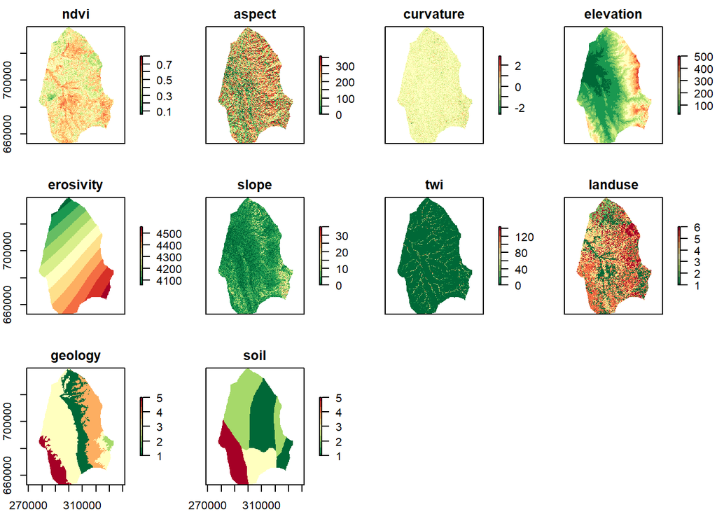

```r
plot(gully_factors_stack, col=rev(MyColour))
```

#reading in shapefile of gully points and non-gully points

```r
gully_pts <- st_read("F:/DA/R/Gully_dataset/gully_tr_pts.shp", quiet = T)
```

```r
non_gully_pts <- st_read("F:/DA/R/Gully_dataset/non_gully_tr_pts.shp", quiet = T)
```

#reading in shapefile of gully points and non-gully points

```r
summary(gully_pts)
```

```
##     OBJECTID       pointid          gng             geometry
##  Min.   :   1   Min.   :   1   Min.   :1   POINT        :4781
##  1st Qu.:1196   1st Qu.:1196   1st Qu.:1   epsg:32632   :   0
##  Median :2391   Median :2391   Median :1   +proj=utm ...:   0
##  Mean   :2391   Mean   :2391   Mean   :1
##  3rd Qu.:3586   3rd Qu.:3586   3rd Qu.:1
##  Max.   :4781   Max.   :4781   Max.   :1
```

```r
summary(non_gully_pts)
```

```
##       OID_        gng             geometry
##  Min.   :0   Min.   :0   POINT        :4781
##  1st Qu.:0   1st Qu.:0   epsg:32632   :   0
##  Median :0   Median :0   +proj=utm ...:   0
##  Mean   :0   Mean   :0
##  3rd Qu.:0   3rd Qu.:0
##  Max.   :0   Max.   :0
```

```r
library(terra)
```

```r
library(ggplot2)
```

```r
library(terra)
```

```r
library(tidyterra)
```

#plotting the distribution of training points

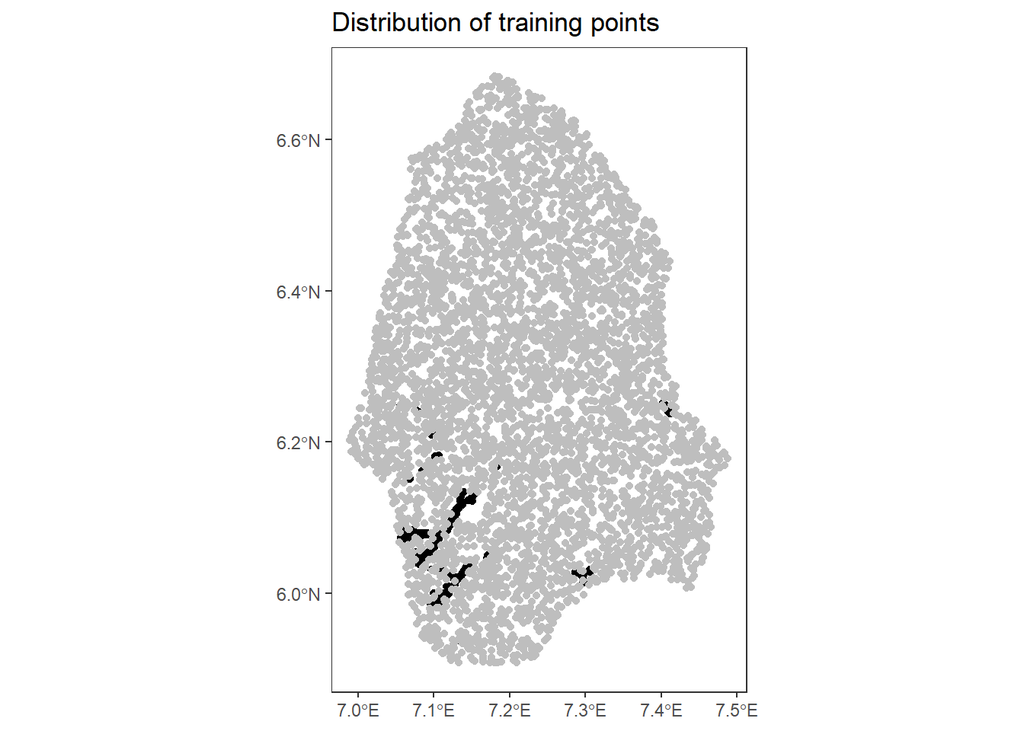

```r
ggplot()+
  theme_bw()+
  theme(panel.grid.major = element_blank())+
  geom_sf (data=gully_pts, color="black")+
  geom_sf(data=non_gully_pts, color="grey")+
  ggtitle ("Distribution of training points")+
  coord_sf()
```

#converting ndvi to terra raster

```r
ndvi_t <-rast(ndvi)
```

#plotting the distribution of training points over one raster

```
## <SpatRaster> resampled to 500335 cells.
```

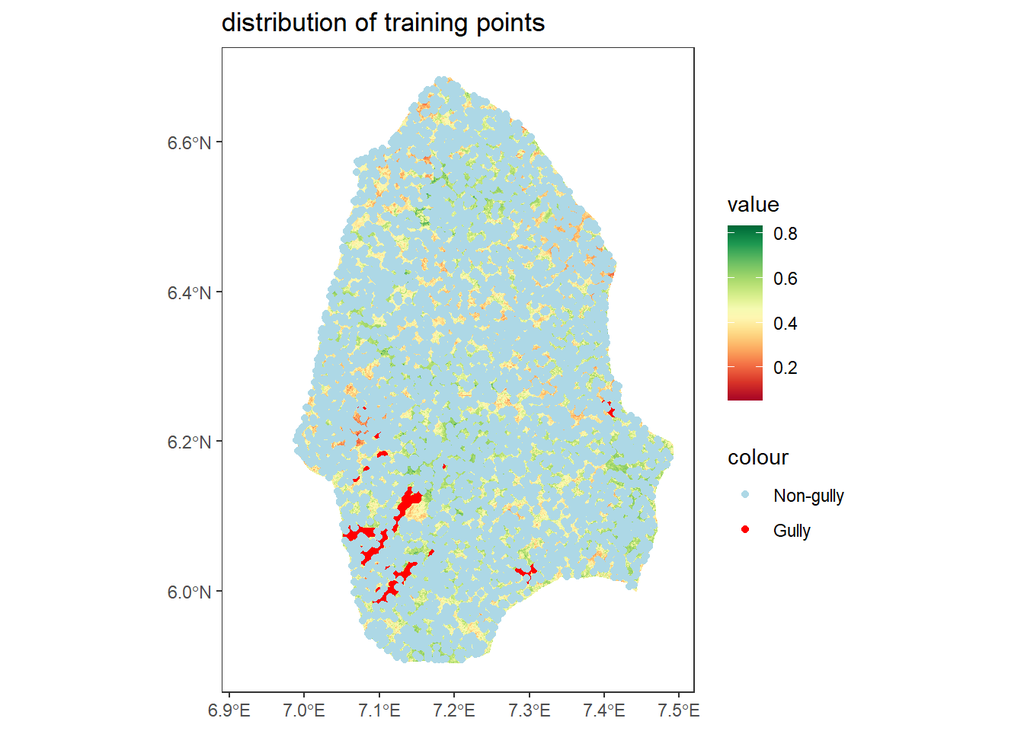

```r
ggplot()+
  theme_bw()+
  theme(panel.grid.major = element_blank())+
  geom_spatraster(data=ndvi_t)+
  geom_sf (data=gully_pts, aes(col="red"))+
  geom_sf(data=non_gully_pts, aes(col="lightblue"))+
  scale_fill_gradientn(colours=MyPalette(20), na.value=NA)+
  scale_color_identity(labels=c(red="Gully", lightblue="Non-gully"), guide="legend")+
  ggtitle ("distribution of training points")+
  coord_sf()
```

#extracting the attribute presence/absence from the imported shapefiles

```r
gully <-gully_pts$gng
```

```r
non_gully <- non_gully_pts$gng
```

#converting imported shapefile to a spatial feature

```r
g_pts_sp <-as(gully_pts, 'Spatial')
```

```r
ng_pts_sp <-as(non_gully_pts, 'Spatial')
```

#extracting values from the stacked raster file to the shape file of gully occurrences

```r
gully_ext <- raster::extract(gully_factors_stack, g_pts_sp, method="simple")
```

```r
head(gully_ext)
```

```
##           ndvi   aspect  curvature elevation erosivity    slope      twi
## [1,] 0.2953531 117.6460 -0.8888889        63  4248.605 5.641220 43.43210
## [2,] 0.2808002 125.9097 -1.0000000        64  4248.622 8.485238 43.22222
## [3,] 0.3576722 184.0856  0.0000000        82  4247.791 6.671227  0.00000
## [4,] 0.3224722 182.4895 -0.2222222        82  4247.915 5.479269  0.00000
## [5,] 0.3448715 144.4623  0.1111111        82  4248.038 4.100294  0.00000
## [6,] 0.3169509 129.8056 -0.1111111        80  4248.161 3.723867  0.00000
##      landuse geology soil
## [1,]       6       3    5
## [2,]       6       3    5
## [3,]       6       3    5
## [4,]       6       3    5
## [5,]       4       3    5
## [6,]       6       3    5
```

```r
tail(gully_ext)
```

```
##              ndvi   aspect  curvature elevation erosivity    slope       twi
## [4776,] 0.4126712 161.5650  0.0000000       233  4419.060 5.269658 0.3703704
## [4777,] 0.4204545 165.9638 -0.2222222       230  4419.272 1.967864 0.3703704
## [4778,] 0.4139379 163.0725  0.8888889       230  4419.485 5.720433 1.8888890
## [4779,] 0.4481808 160.4633  0.0000000       225  4419.584 7.804185 3.5555556
## [4780,] 0.4094853 195.7512  0.1111111       210  4421.457 9.583437 0.0000000
## [4781,] 0.3486989 180.0000 -0.1111111       205  4421.672 9.926246 0.0000000
##         landuse geology soil
## [4776,]       4       5    5
## [4777,]       4       5    5
## [4778,]       4       5    5
## [4779,]       4       5    5
## [4780,]       4       5    5
## [4781,]       6       5    5
```

```r
summary(gully_ext)
```

```
##       ndvi            aspect         curvature         elevation
##  Min.   :0.1659   Min.   : -1.00   Min.   :-4.3333   Min.   : 55.0
##  1st Qu.:0.3001   1st Qu.: 49.76   1st Qu.:-0.3333   1st Qu.: 97.0
##  Median :0.3806   Median :127.57   Median :-0.1111   Median :121.0
##  Mean   :0.3915   Mean   :134.01   Mean   :-0.1463   Mean   :136.8
##  3rd Qu.:0.4707   3rd Qu.:180.00   3rd Qu.: 0.1111   3rd Qu.:179.0
##  Max.   :0.8270   Max.   :359.29   Max.   : 2.6667   Max.   :294.0
##    erosivity        slope             twi              landuse
##  Min.   :4248   Min.   : 0.000   Min.   :  0.0000   Min.   :1.000
##  1st Qu.:4338   1st Qu.: 1.350   1st Qu.:  0.3333   1st Qu.:4.000
##  Median :4352   Median : 3.769   Median :  6.4197   Median :5.000
##  Mean   :4360   Mean   : 6.495   Mean   : 26.5244   Mean   :4.526
##  3rd Qu.:4384   3rd Qu.: 9.143   3rd Qu.: 46.2469   3rd Qu.:6.000
##  Max.   :4476   Max.   :43.040   Max.   :134.5062   Max.   :6.000
##     geology           soil
##  Min.   :1.000   Min.   :2.000
##  1st Qu.:3.000   1st Qu.:5.000
##  Median :5.000   Median :5.000
##  Mean   :4.252   Mean   :4.732
##  3rd Qu.:5.000   3rd Qu.:5.000
##  Max.   :5.000   Max.   :5.000
```

#extracting values from the stacked raster file to the shape file of non-gully points

```r
ng_ext <- raster::extract(gully_factors_stack, ng_pts_sp, method="simple")
```

```r
head(ng_ext)
```

```
##           ndvi   aspect  curvature elevation erosivity     slope       twi
## [1,] 0.5462478 241.6992 -0.1111111       130  4162.293  3.520405 0.2098766
## [2,] 0.4923741  -1.0000  0.0000000        64  4367.822  0.000000 0.2222222
## [3,] 0.3758815 260.5377  0.0000000       294  4240.436  2.901822 0.0000000
## [4,] 0.4221106 302.4712  0.0000000       240  4433.352  6.201054 0.1728395
## [5,] 0.3511561 299.0546  0.2222222        65  4333.307  2.456395 0.0000000
## [6,] 0.4085028 195.3501  0.4444444       309  4543.173 23.784155 0.1728395
##      landuse geology soil
## [1,]       5       1    2
## [2,]       4       3    5
## [3,]       4       4    1
## [4,]       6       1    1
## [5,]       6       1    1
## [6,]       6       3    1
```

#appending presence/absence (1/0) information to the data extracted from the raster

```r
g_ext_df <- data.frame(gully_ext, gully)
```

```r
ng_ext_df <- data.frame(ng_ext, non_gully)
```

#naming the column

```r
colnames(g_ext_df)[11] <- "presence_absence"
```

```r
colnames(ng_ext_df)[11] <- "presence_absence"
```

#combining extracted data for gully points and non-gully points

```r
training_pts <- rbind(g_ext_df, ng_ext_df)
```

```r
head(training_pts)
```

```
##        ndvi   aspect  curvature elevation erosivity    slope      twi landuse
## 1 0.2953531 117.6460 -0.8888889        63  4248.605 5.641220 43.43210       6
## 2 0.2808002 125.9097 -1.0000000        64  4248.622 8.485238 43.22222       6
## 3 0.3576722 184.0856  0.0000000        82  4247.791 6.671227  0.00000       6
## 4 0.3224722 182.4895 -0.2222222        82  4247.915 5.479269  0.00000       6
## 5 0.3448715 144.4623  0.1111111        82  4248.038 4.100294  0.00000       4
## 6 0.3169509 129.8056 -0.1111111        80  4248.161 3.723867  0.00000       6
##   geology soil presence_absence
## 1       3    5                1
## 2       3    5                1
## 3       3    5                1
## 4       3    5                1
## 5       3    5                1
## 6       3    5                1
```

```r
summary(training_pts)
```

```
##       ndvi            aspect         curvature          elevation
##  Min.   :0.1255   Min.   : -1.00   Min.   :-4.33333   Min.   : 27.0
##  1st Qu.:0.3464   1st Qu.: 64.65   1st Qu.:-0.22222   1st Qu.: 85.0
##  Median :0.4332   Median :147.80   Median : 0.00000   Median :122.0
##  Mean   :0.4310   Mean   :157.15   Mean   :-0.07478   Mean   :146.2
##  3rd Qu.:0.5178   3rd Qu.:249.78   3rd Qu.: 0.11111   3rd Qu.:193.2
##  Max.   :0.8270   Max.   :359.29   Max.   : 2.66667   Max.   :471.0
##  NA's   :1        NA's   :2        NA's   :2          NA's   :2
##    erosivity        slope             twi              landuse
##  Min.   :4061   Min.   : 0.000   Min.   :  0.0000   Min.   :1.000
##  1st Qu.:4300   1st Qu.: 1.432   1st Qu.:  0.0000   1st Qu.:4.000
##  Median :4349   Median : 3.110   Median :  0.3704   Median :4.000
##  Mean   :4337   Mean   : 5.189   Mean   : 14.8474   Mean   :4.172
##  3rd Qu.:4385   3rd Qu.: 6.423   3rd Qu.: 12.0340   3rd Qu.:5.000
##  Max.   :4553   Max.   :43.040   Max.   :134.5062   Max.   :6.000
##  NA's   :6      NA's   :2                           NA's   :1
##     geology           soil       presence_absence
##  Min.   :1.000   Min.   :1.000   Min.   :0.0
##  1st Qu.:3.000   1st Qu.:2.000   1st Qu.:0.0
##  Median :3.000   Median :5.000   Median :0.5
##  Mean   :3.604   Mean   :3.515   Mean   :0.5
##  3rd Qu.:5.000   3rd Qu.:5.000   3rd Qu.:1.0
##  Max.   :5.000   Max.   :5.000   Max.   :1.0
##  NA's   :1       NA's   :1
```

```r
names(training_pts)
```

```
##  [1] "ndvi"             "aspect"           "curvature"        "elevation"
##  [5] "erosivity"        "slope"            "twi"              "landuse"
##  [9] "geology"          "soil"             "presence_absence"
```

```r
par(mfrow=c(2,5))
```

#checking the distribution of continuous factors in both gully and non-gully points

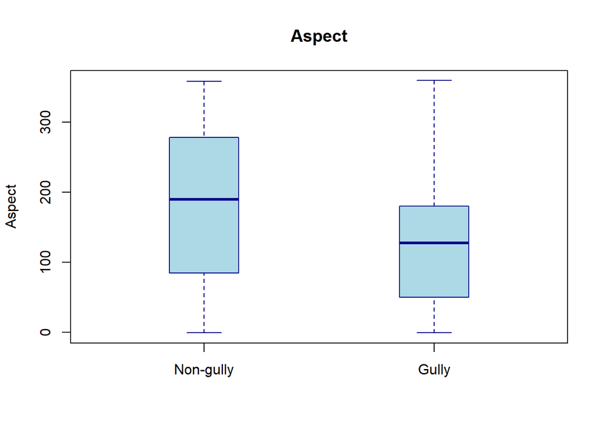

```r
boxplot(aspect ~ presence_absence, data=training_pts, main= "Aspect", xlab=" ", ylab="Aspect", boxwex=0.3, col="lightblue", border="darkblue", names=c("Non-gully", "Gully"))
```

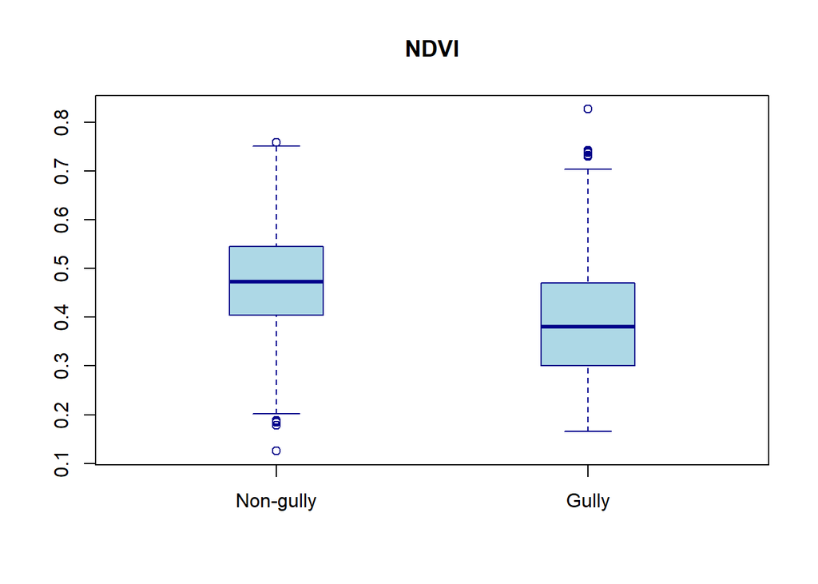

```r
boxplot(ndvi ~ presence_absence, data=training_pts,main= "NDVI", xlab=" ", ylab=" ", boxwex=0.3, col="lightblue", border="darkblue", names=c("Non-gully", "Gully"))
```

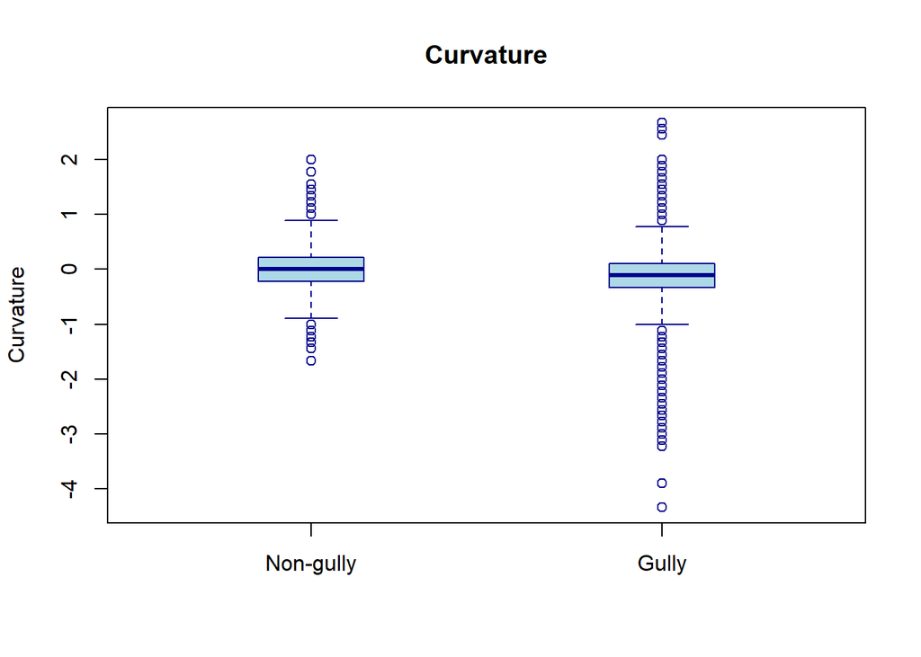

```r
boxplot(curvature ~ presence_absence, data=training_pts, main="Curvature", xlab=" ", ylab="Curvature", boxwex=0.3, col="lightblue", border="darkblue", names=c("Non-gully", "Gully"))
```

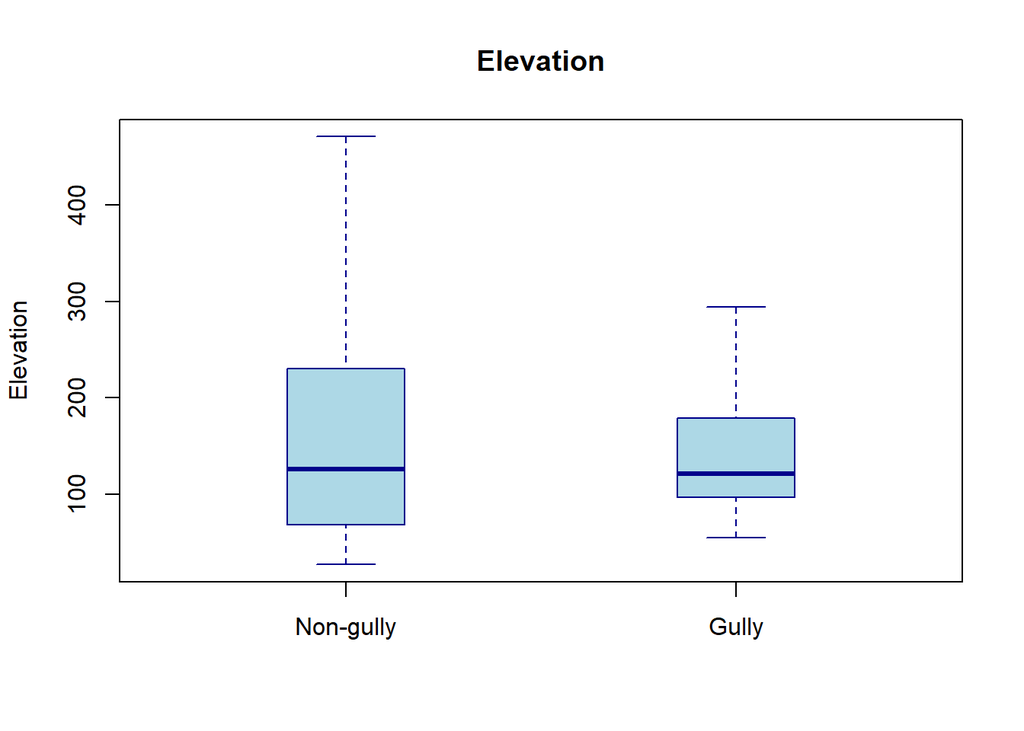

```r
boxplot(elevation ~ presence_absence, data=training_pts, main="Elevation", xlab=" ", ylab="Elevation", boxwex=0.3, col="lightblue", border="darkblue", names=c("Non-gully", "Gully"))
```

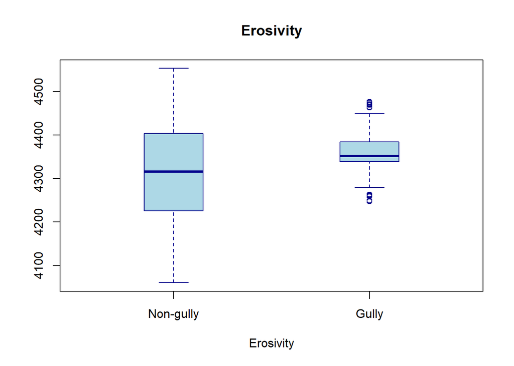

```r
boxplot(erosivity ~ presence_absence, data=training_pts, main="Erosivity", xlab="Erosivity", ylab="", boxwex=0.3, col="lightblue", border="darkblue", names=c("Non-gully", "Gully"))
```

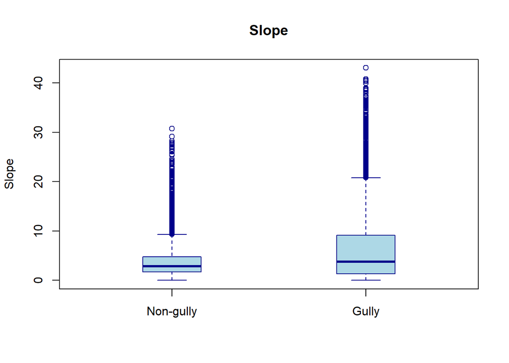

```r
boxplot(slope ~ presence_absence, data=training_pts, main="Slope", xlab=" ", ylab="Slope", boxwex=0.3, col="lightblue", border="darkblue", names=c("Non-gully", "Gully"))
```

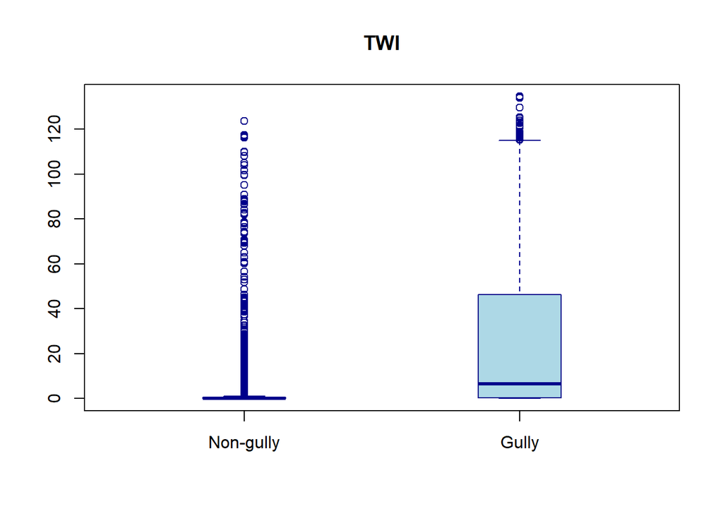

```r
boxplot(twi ~ presence_absence, data=training_pts, main="TWI", xlab=" ", ylab=" ", boxwex=0.3, col="lightblue", border="darkblue", names=c("Non-gully", "Gully"))
```

```r
par(mfrow=c(1,1))
```

#checking the number of samples in class i.e gully and non-gully points

```r
aggregate(training_pts$soil ~training_pts$presence_absence, FUN=length)
```

```
##   training_pts$presence_absence training_pts$soil
## 1                             0              4780
## 2                             1              4781
```

#remove few NAs introduced due to points at the edges study area and duplicated training data

```r
training_pts1 <- na.omit(training_pts)
```

#converting categorical data to factor data type

```r
training_pts1$landuse <-as.factor(training_pts1$landuse)
```

```r
training_pts1$geology <-as.factor(training_pts1$geology)
```

```r
training_pts1$soil <-as.factor(training_pts1$soil)
```

```r
levels(training_pts1$geology)
```

```
## [1] "1" "2" "3" "4" "5"
```

```r
library(caret)
```

#implement one hot coding for categorical data

```r
dummy <- dummyVars(" ~ .", data=training_pts1)
```

```r
training_df <- data.frame(predict(dummy, newdata=training_pts1))
```

```r
training_df %>%
  head(n=3)
```

```
##        ndvi   aspect  curvature elevation erosivity    slope      twi landuse.1
## 1 0.2953531 117.6460 -0.8888889        63  4248.605 5.641220 43.43210         0
## 2 0.2808002 125.9097 -1.0000000        64  4248.622 8.485238 43.22222         0
## 3 0.3576722 184.0856  0.0000000        82  4247.791 6.671227  0.00000         0
##   landuse.2 landuse.3 landuse.4 landuse.5 landuse.6 geology.1 geology.2
## 1         0         0         0         0         1         0         0
## 2         0         0         0         0         1         0         0
## 3         0         0         0         0         1         0         0
##   geology.3 geology.4 geology.5 soil.1 soil.2 soil.3 soil.5 presence_absence
## 1         1         0         0      0      0      0      1                1
## 2         1         0         0      0      0      0      1                1
## 3         1         0         0      0      0      0      1                1
```

```r
names(training_df)
```

```
##  [1] "ndvi"             "aspect"           "curvature"        "elevation"
##  [5] "erosivity"        "slope"            "twi"              "landuse.1"
##  [9] "landuse.2"        "landuse.3"        "landuse.4"        "landuse.5"
## [13] "landuse.6"        "geology.1"        "geology.2"        "geology.3"
## [17] "geology.4"        "geology.5"        "soil.1"           "soil.2"
## [21] "soil.3"           "soil.5"           "presence_absence"
```

#Split data into training and test

```r
training_df$random<-runif(length(training_df$presence_absence))
```

#runif function provides information about the uniform distribution on the interval #from min to max, to generate random deviates.

```r
train<-training_df[training_df$random<0.70, 1:23] ## the training data
```

```r
evalu<-training_df[training_df$random>=0.70, 1:23] ## the evaluation data
```

```r
nrow(train)
```

```
## [1] 6652
```

```r
nrow(evalu)
```

```
## [1] 2904
```

```r
names(train)
```

```
##  [1] "ndvi"             "aspect"           "curvature"        "elevation"
##  [5] "erosivity"        "slope"            "twi"              "landuse.1"
##  [9] "landuse.2"        "landuse.3"        "landuse.4"        "landuse.5"
## [13] "landuse.6"        "geology.1"        "geology.2"        "geology.3"
## [17] "geology.4"        "geology.5"        "soil.1"           "soil.2"
## [21] "soil.3"           "soil.5"           "presence_absence"
```

```r
names(evalu)
```

```
##  [1] "ndvi"             "aspect"           "curvature"        "elevation"
##  [5] "erosivity"        "slope"            "twi"              "landuse.1"
##  [9] "landuse.2"        "landuse.3"        "landuse.4"        "landuse.5"
## [13] "landuse.6"        "geology.1"        "geology.2"        "geology.3"
## [17] "geology.4"        "geology.5"        "soil.1"           "soil.2"
## [21] "soil.3"           "soil.5"           "presence_absence"
```

```r
library(MASS)
log_model <- suppressWarnings(glm(presence_absence~., data=train, family="binomial")%>% stepAIC(trace=FALSE))
```

```r
summary(log_model)
```

```
##
## Call:
## glm(formula = presence_absence ~ ndvi + aspect + curvature +
##     elevation + erosivity + slope + twi + landuse.1 + landuse.2 +
##     landuse.3 + landuse.4 + landuse.5 + geology.1 + geology.2 +
##     geology.3 + geology.4 + soil.1 + soil.2 + soil.3, family = "binomial",
##     data = train)
##
## Coefficients:
##               Estimate Std. Error z value Pr(>|z|)
## (Intercept) -8.688e+01  4.727e+00 -18.381  < 2e-16 ***
## ndvi        -9.131e+00  8.066e-01 -11.321  < 2e-16 ***
## aspect      -4.818e-03  4.857e-04  -9.918  < 2e-16 ***
## curvature   -4.816e-01  1.245e-01  -3.867  0.00011 ***
## elevation   -1.535e-02  1.248e-03 -12.297  < 2e-16 ***
## erosivity    2.200e-02  1.134e-03  19.395  < 2e-16 ***
## slope        1.559e-01  1.236e-02  12.610  < 2e-16 ***
## twi          3.905e-02  3.108e-03  12.563  < 2e-16 ***
## landuse.1   -7.050e-01  2.707e-01  -2.604  0.00920 **
## landuse.2   -9.544e-01  4.683e-01  -2.038  0.04155 *
## landuse.3   -4.164e+00  1.336e+00  -3.116  0.00183 **
## landuse.4   -6.991e-01  1.775e-01  -3.938 8.21e-05 ***
## landuse.5   -2.038e+00  1.904e-01 -10.702  < 2e-16 ***
## geology.1   -2.713e+00  2.823e-01  -9.612  < 2e-16 ***
## geology.2   -1.922e+01  1.186e+03  -0.016  0.98707
## geology.3   -1.389e+00  1.667e-01  -8.337  < 2e-16 ***
## geology.4   -3.579e+00  4.159e-01  -8.605  < 2e-16 ***
## soil.1      -2.084e+01  2.418e+02  -0.086  0.93130
## soil.2      -2.286e+00  1.706e-01 -13.402  < 2e-16 ***
## soil.3      -2.135e+00  1.806e-01 -11.819  < 2e-16 ***
## ---
## Signif. codes:  0 '***' 0.001 '**' 0.01 '*' 0.05 '.' 0.1 ' ' 1
##
## (Dispersion parameter for binomial family taken to be 1)
##
##     Null deviance: 9221.6  on 6651  degrees of freedom
## Residual deviance: 2761.0  on 6632  degrees of freedom
## AIC: 2801
##
## Number of Fisher Scoring iterations: 18
```

#Predicting the probabilities for test data

```r
evalu$lr_pred <-log_model%>% predict(evalu, type="response")
```

```r
summary(evalu)
```

```
##       ndvi            aspect         curvature          elevation
##  Min.   :0.1659   Min.   : -1.00   Min.   :-3.11111   Min.   : 27.0
##  1st Qu.:0.3491   1st Qu.: 63.43   1st Qu.:-0.22222   1st Qu.: 86.0
##  Median :0.4337   Median :146.31   Median : 0.00000   Median :122.0
##  Mean   :0.4308   Mean   :155.34   Mean   :-0.06853   Mean   :146.1
##  3rd Qu.:0.5144   3rd Qu.:245.76   3rd Qu.: 0.11111   3rd Qu.:195.0
##  Max.   :0.7375   Max.   :359.14   Max.   : 2.55556   Max.   :445.0
##    erosivity        slope             twi             landuse.1
##  Min.   :4061   Min.   : 0.000   Min.   :  0.0000   Min.   :0.000
##  1st Qu.:4300   1st Qu.: 1.392   1st Qu.:  0.0000   1st Qu.:0.000
##  Median :4349   Median : 3.110   Median :  0.3642   Median :0.000
##  Mean   :4337   Mean   : 5.237   Mean   : 14.9534   Mean   :0.156
##  3rd Qu.:4385   3rd Qu.: 6.458   3rd Qu.: 12.1204   3rd Qu.:0.000
##  Max.   :4551   Max.   :43.040   Max.   :133.9506   Max.   :1.000
##    landuse.2         landuse.3   landuse.4        landuse.5
##  Min.   :0.00000   Min.   :0   Min.   :0.0000   Min.   :0.0000
##  1st Qu.:0.00000   1st Qu.:0   1st Qu.:0.0000   1st Qu.:0.0000
##  Median :0.00000   Median :0   Median :0.0000   Median :0.0000
##  Mean   :0.03444   Mean   :0   Mean   :0.3385   Mean   :0.2373
##  3rd Qu.:0.00000   3rd Qu.:0   3rd Qu.:1.0000   3rd Qu.:0.0000
##  Max.   :1.00000   Max.   :0   Max.   :1.0000   Max.   :1.0000
##    landuse.6        geology.1        geology.2          geology.3
##  Min.   :0.0000   Min.   :0.0000   Min.   :0.000000   Min.   :0.0000
##  1st Qu.:0.0000   1st Qu.:0.0000   1st Qu.:0.000000   1st Qu.:0.0000
##  Median :0.0000   Median :0.0000   Median :0.000000   Median :0.0000
##  Mean   :0.2338   Mean   :0.1157   Mean   :0.007231   Mean   :0.3988
##  3rd Qu.:0.0000   3rd Qu.:0.0000   3rd Qu.:0.000000   3rd Qu.:1.0000
##  Max.   :1.0000   Max.   :1.0000   Max.   :1.000000   Max.   :1.0000
##    geology.4        geology.5          soil.1          soil.2
##  Min.   :0.0000   Min.   :0.0000   Min.   :0.000   Min.   :0.0000
##  1st Qu.:0.0000   1st Qu.:0.0000   1st Qu.:0.000   1st Qu.:0.0000
##  Median :0.0000   Median :0.0000   Median :0.000   Median :0.0000
##  Mean   :0.1136   Mean   :0.3647   Mean   :0.166   Mean   :0.2132
##  3rd Qu.:0.0000   3rd Qu.:1.0000   3rd Qu.:0.000   3rd Qu.:0.0000
##  Max.   :1.0000   Max.   :1.0000   Max.   :1.000   Max.   :1.0000
##      soil.3           soil.5       presence_absence    lr_pred
##  Min.   :0.0000   Min.   :0.0000   Min.   :0.0000   Min.   :0.000000
##  1st Qu.:0.0000   1st Qu.:0.0000   1st Qu.:0.0000   1st Qu.:0.003861
##  Median :0.0000   Median :1.0000   Median :0.0000   Median :0.564753
##  Mean   :0.0978   Mean   :0.5231   Mean   :0.4983   Mean   :0.502437
##  3rd Qu.:0.0000   3rd Qu.:1.0000   3rd Qu.:1.0000   3rd Qu.:0.964986
##  Max.   :1.0000   Max.   :1.0000   Max.   :1.0000   Max.   :0.999954
```

#Accuracy assessment through AUC/ROC Plot

```r
library(PresenceAbsence)
pa_validate<-data.frame(ID=1:length(evalu$presence_absence),
                        PA=evalu$presence_absence,
                        logistic=evalu$lr_pred)
```

```r
presence.absence.accuracy(pa_validate, threshold=0.5)
```

```
##      model threshold       PCC sensitivity specificity     Kappa       AUC
## 1 logistic       0.5 0.9176997    0.935038   0.9004804 0.8354174 0.9733731
##        PCC.sd sensitivity.sd specificity.sd  Kappa.sd      AUC.sd
## 1 0.005100672    0.006481271     0.00784532 0.0101922 0.002477295
```

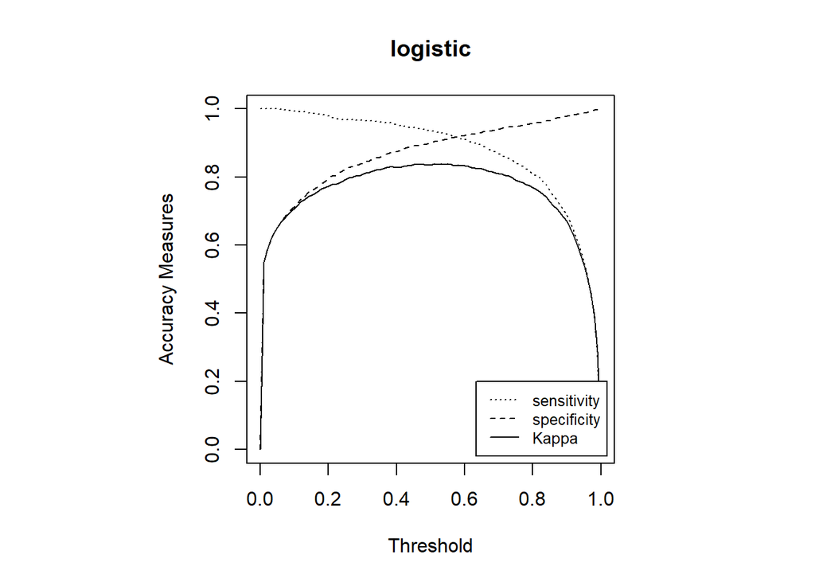

```r
error.threshold.plot(pa_validate,which.model=1)
```

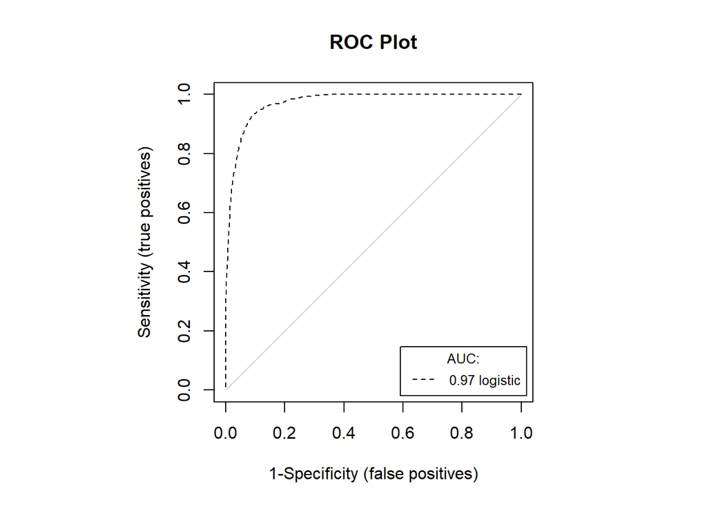

```r
auc.roc.plot(pa_validate)
```

#Accuracy assessment through comparison of mean and confusion matrix #Predictions values <0.5 are converted to 0, >0.5 are converted 1

```r
evalu$lr_pred1<-ifelse(evalu$lr_pred>0.5, "1", "0")
```

```r
mean(evalu$presence_absence==evalu$lr_pred1)
```

```
## [1] 0.9176997
```

```r
confusionMatrix((as.factor(evalu$presence_absence)), (as.factor(evalu$lr_pred1)))
```

```
## Confusion Matrix and Statistics
##
##           Reference
## Prediction    0    1
##          0 1312  145
##          1   94 1353
##
##                Accuracy : 0.9177
##                  95% CI : (0.9071, 0.9274)
##     No Information Rate : 0.5158
##     P-Value [Acc > NIR] : < 2e-16
##
##                   Kappa : 0.8354
##
##  Mcnemar's Test P-Value : 0.00122
##
##             Sensitivity : 0.9331
##             Specificity : 0.9032
##          Pos Pred Value : 0.9005
##          Neg Pred Value : 0.9350
##              Prevalence : 0.4842
##          Detection Rate : 0.4518
##    Detection Prevalence : 0.5017
##       Balanced Accuracy : 0.9182
##
##        'Positive' Class : 0
##
```

#converting the raster stack to a dataframe

```r
raster_df <-terra::as.data.frame(gully_factors_stack, xy=TRUE)
```

```r
raster_df$landuse <-as.factor(raster_df$landuse)
```

```r
raster_df$geology <-as.factor(raster_df$geology)
```

```r
raster_df$soil <-as.factor(raster_df$soil)
```

#applying one hot coding to categorical data

```r
dummy <- dummyVars(" ~ .", data=raster_df)
```

```r
raster_df <- data.frame(predict(dummy, newdata=raster_df))
```

#making prediction for the converted dataframe created from raster files

```r
raster_df$logreg <- log_model %>% predict(raster_df[,3:23], type="response")
```

```r
head(raster_df)
```

```
##          x        y ndvi aspect curvature elevation erosivity slope twi
## 1 277420.9 739703.9   NA     NA        NA        NA        NA    NA  NA
## 2 277450.9 739703.9   NA     NA        NA        NA        NA    NA  NA
## 3 277480.9 739703.9   NA     NA        NA        NA        NA    NA  NA
## 4 277510.9 739703.9   NA     NA        NA        NA        NA    NA  NA
## 5 277540.9 739703.9   NA     NA        NA        NA        NA    NA  NA
## 6 277570.9 739703.9   NA     NA        NA        NA        NA    NA  NA
##   landuse.1 landuse.2 landuse.3 landuse.4 landuse.5 landuse.6 geology.1
## 1        NA        NA        NA        NA        NA        NA        NA
## 2        NA        NA        NA        NA        NA        NA        NA
## 3        NA        NA        NA        NA        NA        NA        NA
## 4        NA        NA        NA        NA        NA        NA        NA
## 5        NA        NA        NA        NA        NA        NA        NA
## 6        NA        NA        NA        NA        NA        NA        NA
##   geology.2 geology.3 geology.4 geology.5 soil.1 soil.2 soil.3 soil.5 logreg
## 1        NA        NA        NA        NA     NA     NA     NA     NA     NA
## 2        NA        NA        NA        NA     NA     NA     NA     NA     NA
## 3        NA        NA        NA        NA     NA     NA     NA     NA     NA
## 4        NA        NA        NA        NA     NA     NA     NA     NA     NA
## 5        NA        NA        NA        NA     NA     NA     NA     NA     NA
## 6        NA        NA        NA        NA     NA     NA     NA     NA     NA
```

#converting the data frame back to raster

```r
gully_ras_logreg <- rasterFromXYZ(raster_df)
```

```r
projection(gully_ras_logreg) <-projection(gully_factors_stack)
```

#Minimum and maximum prediction values

```r
min(gully_ras_logreg$logreg@data@values, na.rm = T)
```

```
## [1] 2.220446e-16
```

```r
cellStats(gully_ras_logreg$logreg, max)
```

```
## [1] 0.9999829
```

#Plot the gully susceptibility map

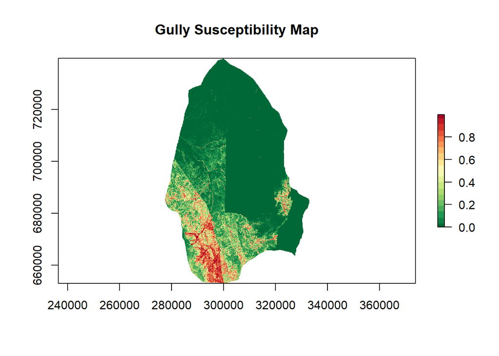

```r
plot(gully_ras_logreg$logreg, main="Gully Susceptibility Map", col=rev(MyPalette(20)))
```